# LipidMS app workflow

Maribel Alcoriza Balaguer

2021-02-04

## LipidMS Overview

LipidMS v2.0.0 is an R-package aimed to confidently identify lipid species in untargeted LC-MS for DIA or DDA data analysis. It combines a set of fragmentation and intensity rules and a parent-to-fragment co-elution score (PFCS, only applied for DIA analysis) calculated in predefined retention time windows. Depending on the MS evidence reached by the annotations, lipids can be identified at three different levels: i) subclasslevel, e.g., PG(34:1); ii) fatty acyl level, e.g., PG(16:0_18:1); and iii) fatty acyl position level, e.g., PG(16:0/18:1). As a general rule, parent ions will be found when no collision energy is applied, while fragment ions will be found when it is. Each lipid class has characteristic ionization and fragmentation properties that allow to filter informative fragments among all fragment ions to reconstruct the parent’s structure. Next figure summarizes the basics of LipidMS.

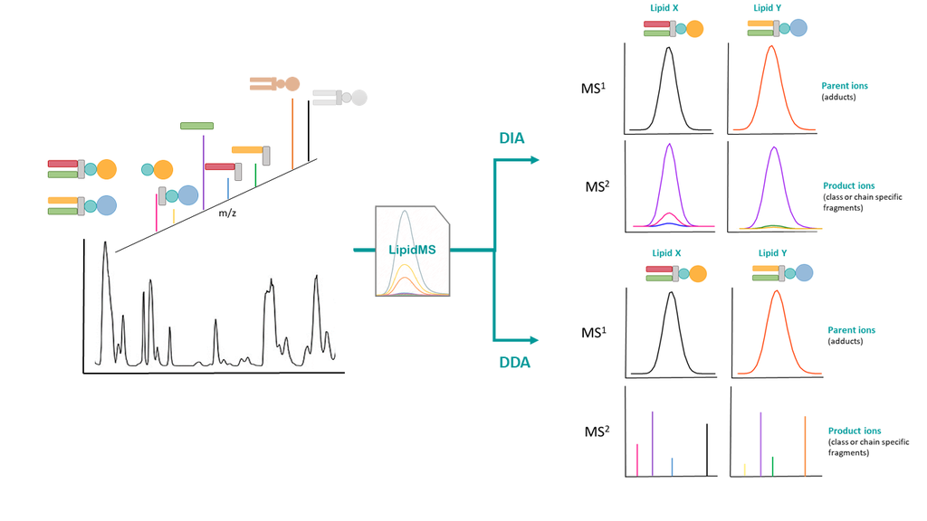

### Installation

The LipidMS application can be accessed locally from R or through our website at (https://www.iislafe.es/es/software/lipidomicstools/lipidomics-tools/). In case you want to run LipidMS locally you need to install the package, otherwise skip this step.

```r
# Install LipidMS and LipidMSdata2
install.packages("LipidMS", dependencies = c("Depends", "Imports"))
devtools::install_github("maialba3/LipidMSdata2")
```

### Files conversion

To start the MS analysis raw files need to be converted into mzXML format first (you can use any software such as MSConvert from proteowizard) and then, LipidMS can be run. Unlike previous versions, LipidMS v2.0 can read mzXML files directly converted from raw files with no additional steps.

### Example data files

Some .mzXML example files are available at (https://www.iislafe.es/es/software/lipidomicstools/about/).

## LipidMS application

### How to run it locally

In case you are working locally on your computer execute the following lines and the app will open on a new window:

```r
# load LipidMS library
library(LipidMS)

# Lunch the app
LipidMSapp()
```

## Data Import

Once all your files have been converted to mzXML and the app is running, upload your files and tune the parameters. At the first tab, data acquisition mode (DIA or DDA) and polarity must be specified:

[figure not shown]

If you have samples acquired with different polarities or acquisition modes, analyze them in different batches.

## Data Processing

At the second tab we find all parameters required for peak-picking. More detailed information about all these parameters can be found at the documentation page of the dataProcessing function.

[figure not shown]

## Annotation

The third tab contains parameters related with the annotation step and lipid classes included in the analysis.

[figure not shown]

## Run

Finally, run your job. You will obtain two csv files with the results tables (the summary table and the whole peak table with annotations) and a pdf files with plots of the peaks supporting those identifications for each one of your files.

If you are using the web application, an email will be required to send your results back. Otherwise, if you are using LipidMSapp() on your computer, you will find three buttons to download your results. Wait until you can see the results on the main panel to download (you may need to write the extension .zip to save your files properly).

[figure not shown]

[figure not shown]

If you have any further questions, please do not hesitate to contact us at: maribel_alcoriza@iislafe.es or maribel_alcoriza@hotmail.com